# Risk Factor Analysis

## Outcome Variable

**Outcome Variable:** haz

## Predictor Variables

**Intervention Variable:** anywast06

**Adjustment Set:**

- arm
- sex
- brthmon
- W_mage
- meducyrs
- hhwealth_quart
- W_nrooms
- month
- W_parity
- delta_W_mage
- delta_meducyrs
- delta_hhwealth_quart
- delta_W_nrooms
- delta_month
- delta_W_parity

## Stratifying Variables

The analysis was stratified on these variable(s):

- agecat
- studyid
- country

## Data Summary

| agecat | studyid | country | anywast06 | n_cell | n |
| --- | --- | --- | --- | --- | --- |
| Birth | ki0047075b-MAL-ED | BANGLADESH | 0 | 177 | 229 |
| Birth | ki0047075b-MAL-ED | BANGLADESH | 1 | 52 | 229 |
| Birth | ki0047075b-MAL-ED | BRAZIL | 0 | 62 | 65 |
| Birth | ki0047075b-MAL-ED | BRAZIL | 1 | 3 | 65 |
| Birth | ki0047075b-MAL-ED | INDIA | 0 | 33 | 47 |
| Birth | ki0047075b-MAL-ED | INDIA | 1 | 14 | 47 |
| Birth | ki0047075b-MAL-ED | NEPAL | 0 | 23 | 27 |
| Birth | ki0047075b-MAL-ED | NEPAL | 1 | 4 | 27 |
| Birth | ki0047075b-MAL-ED | PERU | 0 | 223 | 233 |
| Birth | ki0047075b-MAL-ED | PERU | 1 | 10 | 233 |
| Birth | ki0047075b-MAL-ED | SOUTH AFRICA | 0 | 101 | 122 |
| Birth | ki0047075b-MAL-ED | SOUTH AFRICA | 1 | 21 | 122 |
| Birth | ki0047075b-MAL-ED | TANZANIA, UNITED REPUBLIC OF | 0 | 119 | 124 |
| Birth | ki0047075b-MAL-ED | TANZANIA, UNITED REPUBLIC OF | 1 | 5 | 124 |
| Birth | ki1000108-CMC-V-BCS-2002 | INDIA | 0 | 37 | 92 |
| Birth | ki1000108-CMC-V-BCS-2002 | INDIA | 1 | 55 | 92 |
| Birth | ki1000108-IRC | INDIA | 0 | 164 | 388 |
| Birth | ki1000108-IRC | INDIA | 1 | 224 | 388 |
| Birth | ki1000109-EE | PAKISTAN | 0 | 156 | 240 |
| Birth | ki1000109-EE | PAKISTAN | 1 | 84 | 240 |
| Birth | ki1000109-ResPak | PAKISTAN | 0 | 28 | 42 |
| Birth | ki1000109-ResPak | PAKISTAN | 1 | 14 | 42 |
| Birth | ki1017093b-PROVIDE | BANGLADESH | 0 | 396 | 539 |
| Birth | ki1017093b-PROVIDE | BANGLADESH | 1 | 143 | 539 |
| Birth | ki1101329-Keneba | GAMBIA | 0 | 994 | 1542 |
| Birth | ki1101329-Keneba | GAMBIA | 1 | 548 | 1542 |
| Birth | ki1113344-GMS-Nepal | NEPAL | 0 | 422 | 684 |
| Birth | ki1113344-GMS-Nepal | NEPAL | 1 | 262 | 684 |
| Birth | ki1114097-CMIN | BANGLADESH | 0 | 15 | 20 |
| Birth | ki1114097-CMIN | BANGLADESH | 1 | 5 | 20 |

[output cut: 70 more lines]

The following strata were considered:

- agecat: 24 months, studyid: ki0047075b-MAL-ED, country: BANGLADESH
- agecat: 24 months, studyid: ki0047075b-MAL-ED, country: BRAZIL
- agecat: 24 months, studyid: ki0047075b-MAL-ED, country: INDIA
- agecat: 24 months, studyid: ki0047075b-MAL-ED, country: NEPAL
- agecat: 24 months, studyid: ki0047075b-MAL-ED, country: PERU
- agecat: 24 months, studyid: ki0047075b-MAL-ED, country: SOUTH AFRICA
- agecat: 24 months, studyid: ki0047075b-MAL-ED, country: TANZANIA, UNITED REPUBLIC OF
- agecat: 24 months, studyid: ki1000108-CMC-V-BCS-2002, country: INDIA
- agecat: 24 months, studyid: ki1000108-IRC, country: INDIA
- agecat: 24 months, studyid: ki1000109-EE, country: PAKISTAN
- agecat: 24 months, studyid: ki1017093b-PROVIDE, country: BANGLADESH
- agecat: 24 months, studyid: ki1066203-TanzaniaChild2, country: TANZANIA, UNITED REPUBLIC OF
- agecat: 24 months, studyid: ki1101329-Keneba, country: GAMBIA
- agecat: 24 months, studyid: ki1113344-GMS-Nepal, country: NEPAL
- agecat: 24 months, studyid: ki1114097-CMIN, country: BANGLADESH
- agecat: 24 months, studyid: ki1114097-CONTENT, country: PERU
- agecat: 6 months, studyid: ki0047075b-MAL-ED, country: BANGLADESH
- agecat: 6 months, studyid: ki0047075b-MAL-ED, country: BRAZIL
- agecat: 6 months, studyid: ki0047075b-MAL-ED, country: INDIA
- agecat: 6 months, studyid: ki0047075b-MAL-ED, country: NEPAL
- agecat: 6 months, studyid: ki0047075b-MAL-ED, country: PERU
- agecat: 6 months, studyid: ki0047075b-MAL-ED, country: SOUTH AFRICA
- agecat: 6 months, studyid: ki0047075b-MAL-ED, country: TANZANIA, UNITED REPUBLIC OF
- agecat: 6 months, studyid: ki1000108-CMC-V-BCS-2002, country: INDIA
- agecat: 6 months, studyid: ki1000108-IRC, country: INDIA
- agecat: 6 months, studyid: ki1000109-EE, country: PAKISTAN
- agecat: 6 months, studyid: ki1000109-ResPak, country: PAKISTAN
- agecat: 6 months, studyid: ki1017093b-PROVIDE, country: BANGLADESH
- agecat: 6 months, studyid: ki1066203-TanzaniaChild2, country: TANZANIA, UNITED REPUBLIC OF
- agecat: 6 months, studyid: ki1101329-Keneba, country: GAMBIA
- agecat: 6 months, studyid: ki1112895-Guatemala BSC, country: GUATEMALA
- agecat: 6 months, studyid: ki1113344-GMS-Nepal, country: NEPAL
- agecat: 6 months, studyid: ki1114097-CMIN, country: BANGLADESH
- agecat: 6 months, studyid: ki1114097-CONTENT, country: PERU
- agecat: Birth, studyid: ki0047075b-MAL-ED, country: BANGLADESH
- agecat: Birth, studyid: ki0047075b-MAL-ED, country: BRAZIL
- agecat: Birth, studyid: ki0047075b-MAL-ED, country: INDIA
- agecat: Birth, studyid: ki0047075b-MAL-ED, country: NEPAL
- agecat: Birth, studyid: ki0047075b-MAL-ED, country: PERU
- agecat: Birth, studyid: ki0047075b-MAL-ED, country: SOUTH AFRICA
- agecat: Birth, studyid: ki0047075b-MAL-ED, country: TANZANIA, UNITED REPUBLIC OF
- agecat: Birth, studyid: ki1000108-CMC-V-BCS-2002, country: INDIA
- agecat: Birth, studyid: ki1000108-IRC, country: INDIA
- agecat: Birth, studyid: ki1000109-EE, country: PAKISTAN
- agecat: Birth, studyid: ki1000109-ResPak, country: PAKISTAN
- agecat: Birth, studyid: ki1017093b-PROVIDE, country: BANGLADESH
- agecat: Birth, studyid: ki1101329-Keneba, country: GAMBIA
- agecat: Birth, studyid: ki1113344-GMS-Nepal, country: NEPAL
- agecat: Birth, studyid: ki1114097-CMIN, country: BANGLADESH
- agecat: Birth, studyid: ki1114097-CONTENT, country: PERU

### Dropped Strata

Some strata were dropped due to rare outcomes:

- agecat: Birth, studyid: ki0047075b-MAL-ED, country: BRAZIL
- agecat: Birth, studyid: ki0047075b-MAL-ED, country: NEPAL
- agecat: Birth, studyid: ki1114097-CONTENT, country: PERU
- agecat: 6 months, studyid: ki1114097-CONTENT, country: PERU
- agecat: 24 months, studyid: ki1066203-TanzaniaChild2, country: TANZANIA, UNITED REPUBLIC OF
- agecat: 24 months, studyid: ki1114097-CONTENT, country: PERU

## Methods Detail

We’re interested in the causal parameters $E[Y_a]$ for all values of $a \in \mathcal{A}$. These parameters represent the mean outcome if, possibly contrary to fact, we intervened to set all units to have $A=a$. Under the randomization and positivity assumptions, these are identified by the statistical parameters $\psi_a=E_W[E_{Y|A,W}(Y|A=a,W)]$. In addition, we’re interested in the mean of $Y$, $E[Y]$ under no intervention (the observed mean). We will estimate these parameters by using SuperLearner to fit the relevant likelihood factors – $E_{Y|A,W}(Y|A=a,W)$ and $p(A=a|W)$, and then updating our likelihood fit using a joint TMLE.

For unadjusted analyses ($W=\{\}$), initial likelihoods were estimated using Lrnr_glm to estimate the simple $E(Y|A)$ and Lrnr_mean to estimate $p(A)$. For adjusted analyses, a small library containing Lrnr_glmnet, Lrnr_xgboost, and Lrnr_mean was used.

Having estimated these parameters, we will then use the delta method to estimate relative risks and attributable risks relative to a prespecified baseline level of $A$.

# Results Detail

## Results Plots

[figure not shown]

[figure not shown]

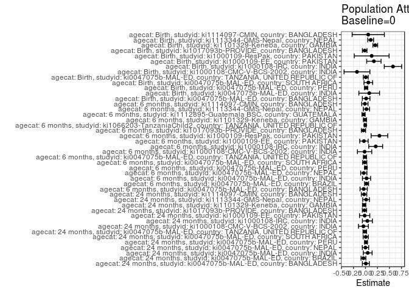

## Results Table

### Parameter: TSM

| agecat | studyid | country | intervention_level | baseline_level | estimate | ci_lower | ci_upper |
| --- | --- | --- | --- | --- | --- | --- | --- |
| Birth | ki0047075b-MAL-ED | BANGLADESH | 0 | NA | -1.1185620 | -1.2666483 | -0.9704757 |
| Birth | ki0047075b-MAL-ED | BANGLADESH | 1 | NA | -1.0740045 | -1.3930952 | -0.7549137 |
| Birth | ki0047075b-MAL-ED | INDIA | 0 | NA | -1.2816422 | -1.6053599 | -0.9579246 |
| Birth | ki0047075b-MAL-ED | INDIA | 1 | NA | -1.0479745 | -1.6916805 | -0.4042685 |
| Birth | ki0047075b-MAL-ED | PERU | 0 | NA | -0.8955773 | -1.0127964 | -0.7783582 |
| Birth | ki0047075b-MAL-ED | PERU | 1 | NA | -1.0055965 | -2.0069585 | -0.0042345 |
| Birth | ki0047075b-MAL-ED | SOUTH AFRICA | 0 | NA | -0.6475654 | -0.8336787 | -0.4614520 |
| Birth | ki0047075b-MAL-ED | SOUTH AFRICA | 1 | NA | -0.2172989 | -0.7081419 | 0.2735441 |
| Birth | ki0047075b-MAL-ED | TANZANIA, UNITED REPUBLIC OF | 0 | NA | -1.1432773 | -1.3541075 | -0.9324471 |
| Birth | ki0047075b-MAL-ED | TANZANIA, UNITED REPUBLIC OF | 1 | NA | -0.9860000 | -2.2167588 | 0.2447588 |
| Birth | ki1000108-CMC-V-BCS-2002 | INDIA | 0 | NA | -0.7845475 | -1.1169407 | -0.4521543 |
| Birth | ki1000108-CMC-V-BCS-2002 | INDIA | 1 | NA | -1.0847130 | -1.3727266 | -0.7966995 |
| Birth | ki1000108-IRC | INDIA | 0 | NA | -0.8810004 | -1.0911282 | -0.6708727 |
| Birth | ki1000108-IRC | INDIA | 1 | NA | 0.1187439 | -0.0988965 | 0.3363843 |
| Birth | ki1000109-EE | PAKISTAN | 0 | NA | -2.0364504 | -2.2452301 | -1.8276708 |
| Birth | ki1000109-EE | PAKISTAN | 1 | NA | -1.4902856 | -1.8858161 | -1.0947550 |
| Birth | ki1000109-ResPak | PAKISTAN | 0 | NA | -1.1095706 | -1.5595928 | -0.6595484 |
| Birth | ki1000109-ResPak | PAKISTAN | 1 | NA | -0.5778319 | -1.5075763 | 0.3519126 |
| Birth | ki1017093b-PROVIDE | BANGLADESH | 0 | NA | -0.8688190 | -0.9544556 | -0.7831825 |
| Birth | ki1017093b-PROVIDE | BANGLADESH | 1 | NA | -0.9607885 | -1.1124973 | -0.8090796 |
| Birth | ki1101329-Keneba | GAMBIA | 0 | NA | -0.1719096 | -0.2464168 | -0.0974024 |
| Birth | ki1101329-Keneba | GAMBIA | 1 | NA | 0.4091262 | 0.2977471 | 0.5205052 |
| Birth | ki1113344-GMS-Nepal | NEPAL | 0 | NA | -1.1541061 | -1.2543676 | -1.0538446 |
| Birth | ki1113344-GMS-Nepal | NEPAL | 1 | NA | -0.8886236 | -1.0103177 | -0.7669295 |
| Birth | ki1114097-CMIN | BANGLADESH | 0 | NA | -1.2613333 | -1.7710980 | -0.7515686 |
| Birth | ki1114097-CMIN | BANGLADESH | 1 | NA | -1.0280000 | -2.2553082 | 0.1993082 |
| 6 months | ki0047075b-MAL-ED | BANGLADESH | 0 | NA | -1.1676910 | -1.2928776 | -1.0425044 |
| 6 months | ki0047075b-MAL-ED | BANGLADESH | 1 | NA | -1.3246033 | -1.6203603 | -1.0288463 |
| 6 months | ki0047075b-MAL-ED | BRAZIL | 0 | NA | 0.0245225 | -0.1247352 | 0.1737802 |
| 6 months | ki0047075b-MAL-ED | BRAZIL | 1 | NA | 0.0578501 | -0.4675545 | 0.5832547 |

[output cut: 58 more lines]

### Parameter: E(Y)

| agecat | studyid | country | intervention_level | baseline_level | estimate | ci_lower | ci_upper |
| --- | --- | --- | --- | --- | --- | --- | --- |
| Birth | ki0047075b-MAL-ED | BANGLADESH | NA | NA | -1.1041048 | -1.2383048 | -0.9699048 |
| Birth | ki0047075b-MAL-ED | INDIA | NA | NA | -1.2036170 | -1.4976814 | -0.9095527 |
| Birth | ki0047075b-MAL-ED | PERU | NA | NA | -0.8827897 | -1.0001058 | -0.7654736 |
| Birth | ki0047075b-MAL-ED | SOUTH AFRICA | NA | NA | -0.5877869 | -0.7622273 | -0.4133464 |
| Birth | ki0047075b-MAL-ED | TANZANIA, UNITED REPUBLIC OF | NA | NA | -1.1369355 | -1.3453337 | -0.9285373 |
| Birth | ki1000108-CMC-V-BCS-2002 | INDIA | NA | NA | -0.9611957 | -1.1776967 | -0.7446946 |
| Birth | ki1000108-IRC | INDIA | NA | NA | -0.3080412 | -0.4687931 | -0.1472894 |
| Birth | ki1000109-EE | PAKISTAN | NA | NA | -1.8608750 | -2.0482045 | -1.6735455 |
| Birth | ki1000109-ResPak | PAKISTAN | NA | NA | -0.9800000 | -1.4086438 | -0.5513562 |
| Birth | ki1017093b-PROVIDE | BANGLADESH | NA | NA | -0.8851020 | -0.9601332 | -0.8100709 |
| Birth | ki1101329-Keneba | GAMBIA | NA | NA | 0.0325486 | -0.0310420 | 0.0961393 |
| Birth | ki1113344-GMS-Nepal | NEPAL | NA | NA | -1.0454532 | -1.1235003 | -0.9674062 |
| Birth | ki1114097-CMIN | BANGLADESH | NA | NA | -1.2030000 | -1.6953191 | -0.7106809 |
| 6 months | ki0047075b-MAL-ED | BANGLADESH | NA | NA | -1.2049931 | -1.3222136 | -1.0877726 |
| 6 months | ki0047075b-MAL-ED | BRAZIL | NA | NA | 0.0475758 | -0.0963508 | 0.1915023 |
| 6 months | ki0047075b-MAL-ED | INDIA | NA | NA | -1.2115254 | -1.3298727 | -1.0931782 |
| 6 months | ki0047075b-MAL-ED | NEPAL | NA | NA | -0.5615819 | -0.6741832 | -0.4489807 |
| 6 months | ki0047075b-MAL-ED | PERU | NA | NA | -1.3236661 | -1.4316775 | -1.2156546 |
| 6 months | ki0047075b-MAL-ED | SOUTH AFRICA | NA | NA | -1.0633202 | -1.1909180 | -0.9357224 |
| 6 months | ki0047075b-MAL-ED | TANZANIA, UNITED REPUBLIC OF | NA | NA | -1.3687449 | -1.4907629 | -1.2467270 |
| 6 months | ki1000108-CMC-V-BCS-2002 | INDIA | NA | NA | -1.4241872 | -1.5668135 | -1.2815609 |
| 6 months | ki1000108-IRC | INDIA | NA | NA | -1.2344062 | -1.3658524 | -1.1029600 |
| 6 months | ki1000109-EE | PAKISTAN | NA | NA | -2.0835567 | -2.2027557 | -1.9643578 |
| 6 months | ki1000109-ResPak | PAKISTAN | NA | NA | -1.4314086 | -1.6374838 | -1.2253335 |
| 6 months | ki1017093b-PROVIDE | BANGLADESH | NA | NA | -1.0916915 | -1.1661176 | -1.0172654 |
| 6 months | ki1066203-TanzaniaChild2 | TANZANIA, UNITED REPUBLIC OF | NA | NA | -0.5434389 | -0.5924056 | -0.4944722 |
| 6 months | ki1101329-Keneba | GAMBIA | NA | NA | -0.9116762 | -0.9588660 | -0.8644864 |
| 6 months | ki1112895-Guatemala BSC | GUATEMALA | NA | NA | -1.5785476 | -1.6926664 | -1.4644288 |
| 6 months | ki1113344-GMS-Nepal | NEPAL | NA | NA | -1.3508392 | -1.4290633 | -1.2726152 |
| 6 months | ki1114097-CMIN | BANGLADESH | NA | NA | -1.7844376 | -1.9222926 | -1.6465825 |
| 24 months | ki0047075b-MAL-ED | BANGLADESH | NA | NA | -1.9783962 | -2.1050210 | -1.8517715 |
| 24 months | ki0047075b-MAL-ED | BRAZIL | NA | NA | 0.0061144 | -0.1625850 | 0.1748138 |
| 24 months | ki0047075b-MAL-ED | INDIA | NA | NA | -1.8861894 | -2.0110006 | -1.7613783 |
| 24 months | ki0047075b-MAL-ED | NEPAL | NA | NA | -1.3075877 | -1.4270718 | -1.1881037 |
| 24 months | ki0047075b-MAL-ED | PERU | NA | NA | -1.7524710 | -1.8736426 | -1.6312994 |
| 24 months | ki0047075b-MAL-ED | SOUTH AFRICA | NA | NA | -1.6450595 | -1.7797240 | -1.5103950 |
| 24 months | ki0047075b-MAL-ED | TANZANIA, UNITED REPUBLIC OF | NA | NA | -2.6455607 | -2.7807256 | -2.5103959 |
| 24 months | ki1000108-CMC-V-BCS-2002 | INDIA | NA | NA | -2.5489071 | -2.6476125 | -2.4502017 |
| 24 months | ki1000108-IRC | INDIA | NA | NA | -1.7987775 | -1.8923914 | -1.7051636 |
| 24 months | ki1000109-EE | PAKISTAN | NA | NA | -2.6699900 | -2.8138051 | -2.5261749 |
| 24 months | ki1017093b-PROVIDE | BANGLADESH | NA | NA | -1.6024221 | -1.6857420 | -1.5191023 |
| 24 months | ki1101329-Keneba | GAMBIA | NA | NA | -1.5774758 | -1.6295950 | -1.5253566 |
| 24 months | ki1113344-GMS-Nepal | NEPAL | NA | NA | -1.8874180 | -1.9728588 | -1.8019773 |
| 24 months | ki1114097-CMIN | BANGLADESH | NA | NA | -2.5109504 | -2.6361514 | -2.3857494 |

### Parameter: ATE

| agecat | studyid | country | intervention_level | baseline_level | estimate | ci_lower | ci_upper |
| --- | --- | --- | --- | --- | --- | --- | --- |
| Birth | ki0047075b-MAL-ED | BANGLADESH | 0 | 0 | 0.0000000 | 0.0000000 | 0.0000000 |
| Birth | ki0047075b-MAL-ED | BANGLADESH | 1 | 0 | 0.0445575 | -0.3072020 | 0.3963171 |
| Birth | ki0047075b-MAL-ED | INDIA | 0 | 0 | 0.0000000 | 0.0000000 | 0.0000000 |
| Birth | ki0047075b-MAL-ED | INDIA | 1 | 0 | 0.2336678 | -0.4916037 | 0.9589392 |
| Birth | ki0047075b-MAL-ED | PERU | 0 | 0 | 0.0000000 | 0.0000000 | 0.0000000 |
| Birth | ki0047075b-MAL-ED | PERU | 1 | 0 | -0.1100192 | -1.1183175 | 0.8982791 |
| Birth | ki0047075b-MAL-ED | SOUTH AFRICA | 0 | 0 | 0.0000000 | 0.0000000 | 0.0000000 |
| Birth | ki0047075b-MAL-ED | SOUTH AFRICA | 1 | 0 | 0.4302665 | -0.0979920 | 0.9585250 |
| Birth | ki0047075b-MAL-ED | TANZANIA, UNITED REPUBLIC OF | 0 | 0 | 0.0000000 | 0.0000000 | 0.0000000 |
| Birth | ki0047075b-MAL-ED | TANZANIA, UNITED REPUBLIC OF | 1 | 0 | 0.1572773 | -1.0914086 | 1.4059632 |
| Birth | ki1000108-CMC-V-BCS-2002 | INDIA | 0 | 0 | 0.0000000 | 0.0000000 | 0.0000000 |
| Birth | ki1000108-CMC-V-BCS-2002 | INDIA | 1 | 0 | -0.3001655 | -0.7415213 | 0.1411902 |
| Birth | ki1000108-IRC | INDIA | 0 | 0 | 0.0000000 | 0.0000000 | 0.0000000 |
| Birth | ki1000108-IRC | INDIA | 1 | 0 | 0.9997443 | 0.6967182 | 1.3027705 |
| Birth | ki1000109-EE | PAKISTAN | 0 | 0 | 0.0000000 | 0.0000000 | 0.0000000 |
| Birth | ki1000109-EE | PAKISTAN | 1 | 0 | 0.5461649 | 0.1021215 | 0.9902083 |
| Birth | ki1000109-ResPak | PAKISTAN | 0 | 0 | 0.0000000 | 0.0000000 | 0.0000000 |
| Birth | ki1000109-ResPak | PAKISTAN | 1 | 0 | 0.5317387 | -0.5130017 | 1.5764792 |
| Birth | ki1017093b-PROVIDE | BANGLADESH | 0 | 0 | 0.0000000 | 0.0000000 | 0.0000000 |
| Birth | ki1017093b-PROVIDE | BANGLADESH | 1 | 0 | -0.0919694 | -0.2661123 | 0.0821735 |
| Birth | ki1101329-Keneba | GAMBIA | 0 | 0 | 0.0000000 | 0.0000000 | 0.0000000 |
| Birth | ki1101329-Keneba | GAMBIA | 1 | 0 | 0.5810357 | 0.4474248 | 0.7146467 |
| Birth | ki1113344-GMS-Nepal | NEPAL | 0 | 0 | 0.0000000 | 0.0000000 | 0.0000000 |
| Birth | ki1113344-GMS-Nepal | NEPAL | 1 | 0 | 0.2654825 | 0.1080104 | 0.4229546 |
| Birth | ki1114097-CMIN | BANGLADESH | 0 | 0 | 0.0000000 | 0.0000000 | 0.0000000 |
| Birth | ki1114097-CMIN | BANGLADESH | 1 | 0 | 0.2333333 | -1.0956307 | 1.5622974 |
| 6 months | ki0047075b-MAL-ED | BANGLADESH | 0 | 0 | 0.0000000 | 0.0000000 | 0.0000000 |
| 6 months | ki0047075b-MAL-ED | BANGLADESH | 1 | 0 | -0.1569123 | -0.4786176 | 0.1647931 |
| 6 months | ki0047075b-MAL-ED | BRAZIL | 0 | 0 | 0.0000000 | 0.0000000 | 0.0000000 |
| 6 months | ki0047075b-MAL-ED | BRAZIL | 1 | 0 | 0.0333276 | -0.5129825 | 0.5796377 |

[output cut: 58 more lines]

### Parameter: PAR

| agecat | studyid | country | intervention_level | baseline_level | estimate | ci_lower | ci_upper |
| --- | --- | --- | --- | --- | --- | --- | --- |
| Birth | ki0047075b-MAL-ED | BANGLADESH | 0 | NA | 0.0144572 | -0.0648953 | 0.0938097 |
| Birth | ki0047075b-MAL-ED | INDIA | 0 | NA | 0.0780252 | -0.1375516 | 0.2936020 |
| Birth | ki0047075b-MAL-ED | PERU | 0 | NA | 0.0127876 | -0.0219173 | 0.0474925 |
| Birth | ki0047075b-MAL-ED | SOUTH AFRICA | 0 | NA | 0.0597785 | -0.0308414 | 0.1503984 |
| Birth | ki0047075b-MAL-ED | TANZANIA, UNITED REPUBLIC OF | 0 | NA | 0.0063418 | -0.0443044 | 0.0569881 |
| Birth | ki1000108-CMC-V-BCS-2002 | INDIA | 0 | NA | -0.1766482 | -0.4460874 | 0.0927911 |
| Birth | ki1000108-IRC | INDIA | 0 | NA | 0.5729592 | 0.3917590 | 0.7541594 |
| Birth | ki1000109-EE | PAKISTAN | 0 | NA | 0.1755754 | 0.0262842 | 0.3248666 |
| Birth | ki1000109-ResPak | PAKISTAN | 0 | NA | 0.1295706 | -0.2332041 | 0.4923453 |
| Birth | ki1017093b-PROVIDE | BANGLADESH | 0 | NA | -0.0162830 | -0.0641790 | 0.0316130 |
| Birth | ki1101329-Keneba | GAMBIA | 0 | NA | 0.2044582 | 0.1550448 | 0.2538716 |
| Birth | ki1113344-GMS-Nepal | NEPAL | 0 | NA | 0.1086529 | 0.0477562 | 0.1695495 |
| Birth | ki1114097-CMIN | BANGLADESH | 0 | NA | 0.0583333 | -0.2769994 | 0.3936660 |
| 6 months | ki0047075b-MAL-ED | BANGLADESH | 0 | NA | -0.0373021 | -0.1127373 | 0.0381331 |
| 6 months | ki0047075b-MAL-ED | BRAZIL | 0 | NA | 0.0230533 | -0.0187917 | 0.0648983 |
| 6 months | ki0047075b-MAL-ED | INDIA | 0 | NA | 0.0227634 | -0.0621854 | 0.1077122 |
| 6 months | ki0047075b-MAL-ED | NEPAL | 0 | NA | -0.0347934 | -0.0993335 | 0.0297468 |
| 6 months | ki0047075b-MAL-ED | PERU | 0 | NA | 0.0089027 | -0.0169793 | 0.0347847 |
| 6 months | ki0047075b-MAL-ED | SOUTH AFRICA | 0 | NA | -0.0152562 | -0.0583541 | 0.0278418 |
| 6 months | ki0047075b-MAL-ED | TANZANIA, UNITED REPUBLIC OF | 0 | NA | -0.0099648 | -0.0431165 | 0.0231869 |
| 6 months | ki1000108-CMC-V-BCS-2002 | INDIA | 0 | NA | -0.0181240 | -0.1675424 | 0.1312944 |
| 6 months | ki1000108-IRC | INDIA | 0 | NA | 0.2131217 | 0.0686809 | 0.3575625 |
| 6 months | ki1000109-EE | PAKISTAN | 0 | NA | -0.0315277 | -0.1195159 | 0.0564604 |
| 6 months | ki1000109-ResPak | PAKISTAN | 0 | NA | 0.2904354 | 0.1172301 | 0.4636406 |
| 6 months | ki1017093b-PROVIDE | BANGLADESH | 0 | NA | -0.0415759 | -0.0858799 | 0.0027281 |
| 6 months | ki1066203-TanzaniaChild2 | TANZANIA, UNITED REPUBLIC OF | 0 | NA | -0.0045643 | -0.0255463 | 0.0164176 |
| 6 months | ki1101329-Keneba | GAMBIA | 0 | NA | -0.0103203 | -0.0432787 | 0.0226381 |
| 6 months | ki1112895-Guatemala BSC | GUATEMALA | 0 | NA | -0.0402049 | -0.0726048 | -0.0078050 |
| 6 months | ki1113344-GMS-Nepal | NEPAL | 0 | NA | 0.0212762 | -0.0439375 | 0.0864899 |
| 6 months | ki1114097-CMIN | BANGLADESH | 0 | NA | -0.0122477 | -0.0777118 | 0.0532164 |
| 24 months | ki0047075b-MAL-ED | BANGLADESH | 0 | NA | 0.0083690 | -0.0643071 | 0.0810451 |
| 24 months | ki0047075b-MAL-ED | BRAZIL | 0 | NA | -0.0417900 | -0.0923056 | 0.0087257 |
| 24 months | ki0047075b-MAL-ED | INDIA | 0 | NA | 0.0471864 | -0.0444264 | 0.1387992 |
| 24 months | ki0047075b-MAL-ED | NEPAL | 0 | NA | 0.0005401 | -0.0654989 | 0.0665791 |
| 24 months | ki0047075b-MAL-ED | PERU | 0 | NA | 0.0115014 | -0.0184534 | 0.0414561 |
| 24 months | ki0047075b-MAL-ED | SOUTH AFRICA | 0 | NA | 0.0057051 | -0.0484481 | 0.0598583 |
| 24 months | ki0047075b-MAL-ED | TANZANIA, UNITED REPUBLIC OF | 0 | NA | -0.0137732 | -0.0509420 | 0.0233955 |
| 24 months | ki1000108-CMC-V-BCS-2002 | INDIA | 0 | NA | -0.0424724 | -0.1454563 | 0.0605114 |
| 24 months | ki1000108-IRC | INDIA | 0 | NA | 0.0406109 | -0.0636854 | 0.1449072 |
| 24 months | ki1000109-EE | PAKISTAN | 0 | NA | -0.0166480 | -0.1235983 | 0.0903022 |
| 24 months | ki1017093b-PROVIDE | BANGLADESH | 0 | NA | -0.0202260 | -0.0646308 | 0.0241788 |
| 24 months | ki1101329-Keneba | GAMBIA | 0 | NA | -0.0274242 | -0.0620329 | 0.0071845 |
| 24 months | ki1113344-GMS-Nepal | NEPAL | 0 | NA | 0.0141119 | -0.0557958 | 0.0840195 |
| 24 months | ki1114097-CMIN | BANGLADESH | 0 | NA | -0.0294846 | -0.0864589 | 0.0274897 |